# Big Data and Pipeline

[Hui Lin](https://scientistcafe.com) @Netlify  
Ming Li @Amazon

2019-09-06

# Empowering data scientist/statistician with engineering education

## Why

- Industry is operating in an environment where mobile/web products and data infrastructure are becoming increasingly sophisticated
- Challenges if without being versed in certain aspects of engineering
  - Communication barrier: pipeline incidents, feature requests, authentication and data ownership
  - Inefficient processing of data, improper use of computation resources
  - Ad hoc investigation by data scientists about the meaning of data
  - Difficulty to put analysis/model to production

# Empowering data scientist/statistician with engineering education

## What

- Data system: how data is generated/stored/computed/monitored
- Data pipeline: how data flow to the database you are currently using
- Logging best practice: logging best practices and schema design
- Experimentation: experiment reporting framework to support product development
- Anomaly detection: use in-house anomaly detection framework
- Coding efficiency: create user define function in spark, coding conventions
- ML tooling

# Empowering data scientist/statistician with engineering education

## How

- Add engineering course to the curriculum
- Internal training program
- Participate in open source community

# Big Data: How big is big?

# Some Statistics

- 1 Gitabyte(GB) = 1024 Megabytes(MB)
- 1 Petabyte(PB) = 1024 Terabytes(TB)
- 1 Exabyte(EB) = 1024 Petabyte(PB)
- PC holds 500 GB
- Netlify
  - 35 GB logs/day (1TB/month, 12TB/year, get to PB in 4 years)
  - 10 millions sites on our platform
- Google ([live statistics](http://www.internetlivestats.com/google-search-statistics/))
  - over 40,000 search queries/second; over 3.5 billion searches/day; 1.2 trillion searches/year(2012)
  - 10-15 EB (data of 30 Million PCs combined!)
  - “Google currently processes over 20 petabytes of data per day through an average of 100,000 MapReduce jobs spread across its massive computing clusters.”[(from a 2017 article)](https://www.heshmore.com/how-much-data-does-google-handle/)

# Move to the Cloud

- Amazon AWS cloud environment
- Microsoft Azure cloud environment
- Google cloud platform

[figure not shown]

# Data Pipeline

[figure not shown]

# Data Science Types v.s Needs

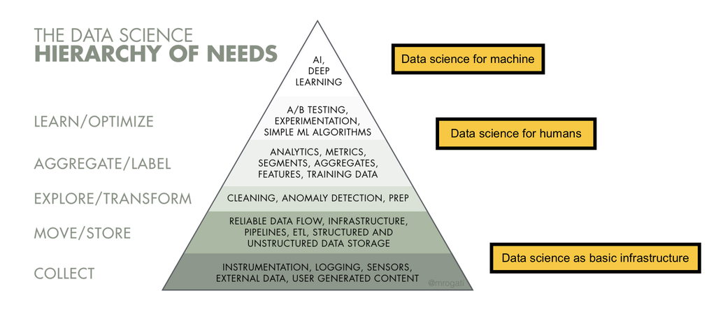

# Hadoop/MapReduce/Spark

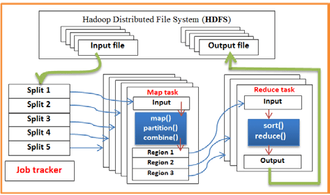